# Maps in R

In this tutorial we’ll cover the following topics:

- Basic Maps
- Heat Maps
- Leaflet Maps

Advanced topic:

- Spatial Data

## Basic Maps

There is no function for displaying maps in the base R functionality. To display a simple map, we use the `maps` package. First, let’s create an Indiana map.

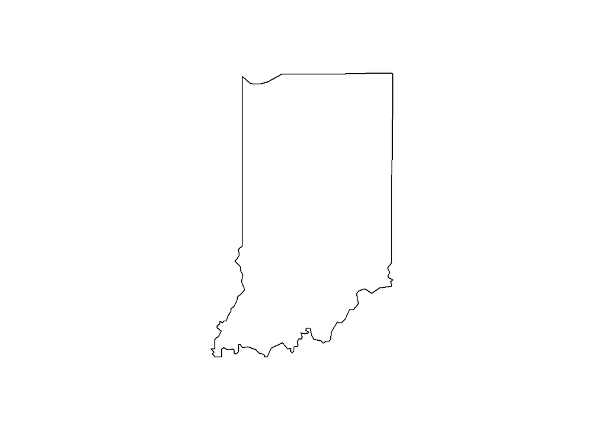

```r
library(maps)
map(database = 'state', regions = 'indiana')
```

Now we can add a few monitors as points. For illustration, I’ve created a simple data frame below, with latitude and longitude information.

```r
monitors <- read.table(header=TRUE, text='
  monitorid        lat        long                       name
          1   41.60668  -87.304729                 Gary-IITRI
          2  39.811097  -86.114469     Indpls-Washington-Park
          3  39.749019  -86.186314         Indpls-Harding-St.
          4  38.013248  -87.577856     Evansville-Buena-Vista
          5  39.159383  -86.504762                Bloomington
          6  39.997484  -86.395172                 Whitestown
                       ')
```

Now we can use the longitude column as the x-axis values and latitude for the y-axis values in the `points()` function. This function adds points to an already existing plot in R.

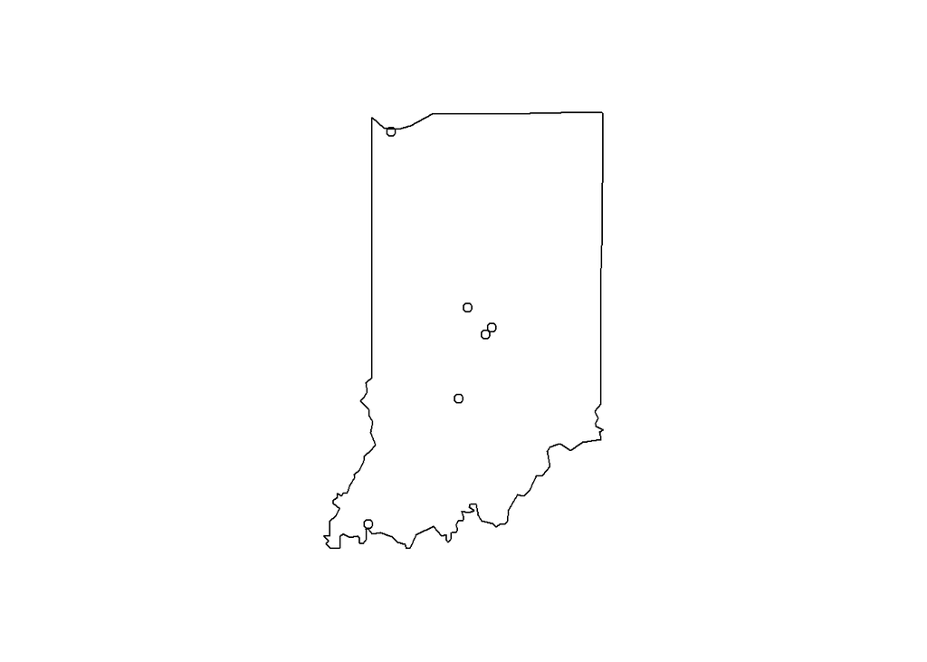

```r
points(x = monitors$long, y = monitors$lat)
```

We can jazz it up a bit by making it a county map and changing the symbol type and color.

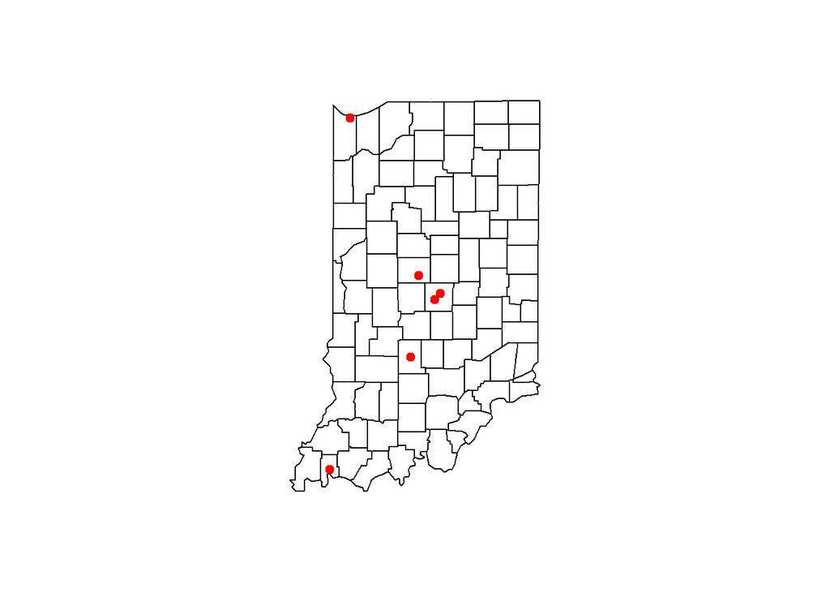

```r
map(database = 'county', regions = 'indiana')
points(x = monitors$long, y = monitors$lat, pch = 19, col = 'red')
```

We can also select specific counties to look at, and give the map a title.

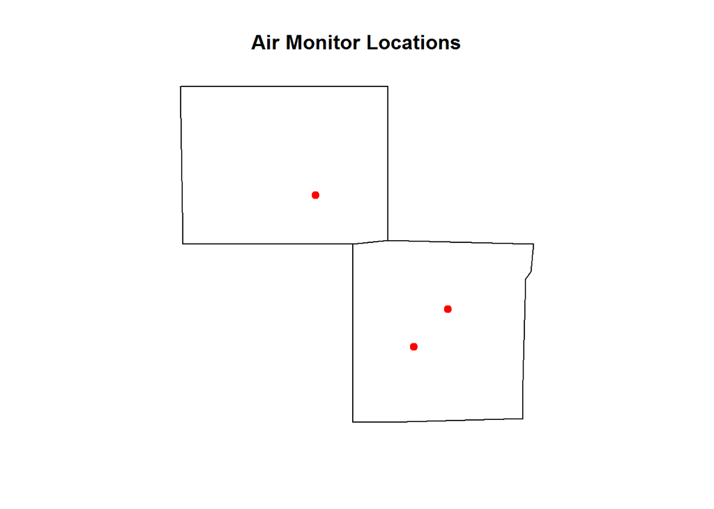

```r
map(database = 'county', regions = c('indiana,marion', 'indiana,boone'))
points(x = monitors$long, y = monitors$lat, pch = 19, col = 'red')
title(main = "Air Monitor Locations")
```

If we want to label the monitors, we use the `text()` function.

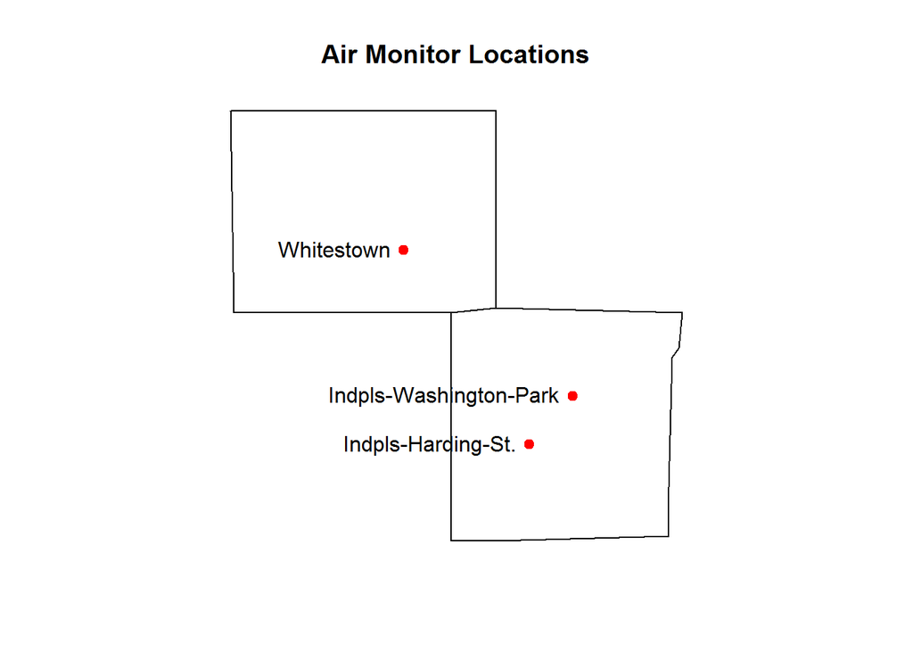

```r
map(database = 'county', regions = c('indiana,marion', 'indiana,boone'))
points(x = monitors$long, y = monitors$lat, pch = 19, col = 'red')
title(main = "Air Monitor Locations")
text(x = monitors$long, y = monitors$lat, labels = monitors$name, pos = 2)
```

## Heat Maps

The `choroplethr` package makes it fairly easy to create heat maps in R. For illustration, here’s a simple data frame of the number of nonattainment areas for 8-hr ozone (2008 standard) by state in Region 5 ([reference](http://www3.epa.gov/airquality/greenbook/hntc.html)).

```r
nonattain <- read.table(header=TRUE, text='
      state  areas
   illinois      2
    indiana      2
   michigan      0
       ohio      3
  wisconsin      2
                      ')
```

Now we’ll use the `choroplethr` package to make a heat map. The `state_choropleth()` function requires the column with state names to be labeled “region” and the column with the numeric values to be labeled “value”. To do this, we’ll introduce another handy `dplyr` function, `rename()`.

```r
library(dplyr)

nonattain <- rename(nonattain, region = state, value = areas)
```

Now we can use the `state_choropleth()` function.

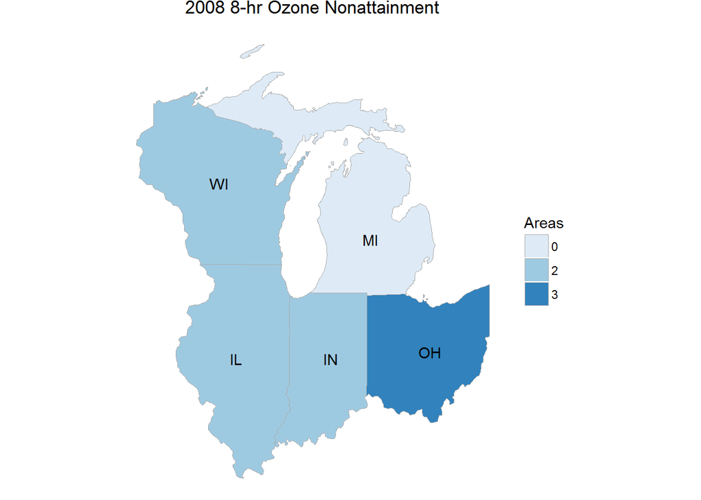

```r
library(choroplethr)
library(choroplethrMaps)

nonattain_map <- state_choropleth(nonattain, zoom = nonattain$region,
                                  title = "2008 8-hr Ozone Nonattainment",
                                  legend = "Areas")
nonattain_map
```

## Leaflet Maps

Leaflet is an interactive map that can be created in R using the `leaflet` package.

```r
library(leaflet)
m <- leaflet()
m <- addTiles(m)
m <- addMarkers(m, lng=monitors$long, lat=monitors$lat,
                popup=monitors$name)
m
```

[interactive chart not shown]

## Exercises

Exercises for this tutorial can be found here: http://rpubs.com/NateByers/MapsExercises.

## Advanced Topic

### Spatial Data

It is possible to perform any kind of geographical analysis in R.

To illustrate how to create spatial data objects in R, let’s re-create the simple `monitors` data frame, with a small modification:

```r
monitors <- read.table(header=TRUE, text='
  monitorid        long        lat     datum                    name
          1  -87.304729   41.60668     WGS84              Gary-IITRI
          2  -86.114469  39.811097     WGS84  Indpls-Washington-Park
          3  -86.186314  39.749019     WGS84      Indpls-Harding-St.
          4  -87.577856  38.013248     NAD83  Evansville-Buena-Vista
          5  -86.504762  39.159383     NAD83             Bloomington
          6  -86.395172  39.997484     NAD83              Whitestown
                       ')
```

Now we have a “datum” column. We’ve also put the longitude column first, followed by the latitude column. And to be precise, before we lump all of these monitors together in a data object, we need to split them up by datum.

```r
mon_WGS84 <- filter(monitors, datum == "WGS84")
mon_NAD83 <- filter(monitors, datum == "NAD83")
```

`sp` is the foundational package for working with spatial data in R. Once we library the package we can create `SpatialPoints` data objects by using the `SpatialPoints()` function.

```r
library(sp)

mon_WGS84_sp <- SpatialPoints(coords = select(mon_WGS84, long, lat),
                              proj4string = CRS("+proj=longlat +ellpsWGS84"))

mon_NAD83_sp <- SpatialPoints(coords = select(mon_NAD83, long, lat),
                              proj4string = CRS("+proj=longlat +ellpsNAD83"))
```

Now we can plot the `SpatialPoints` objects.

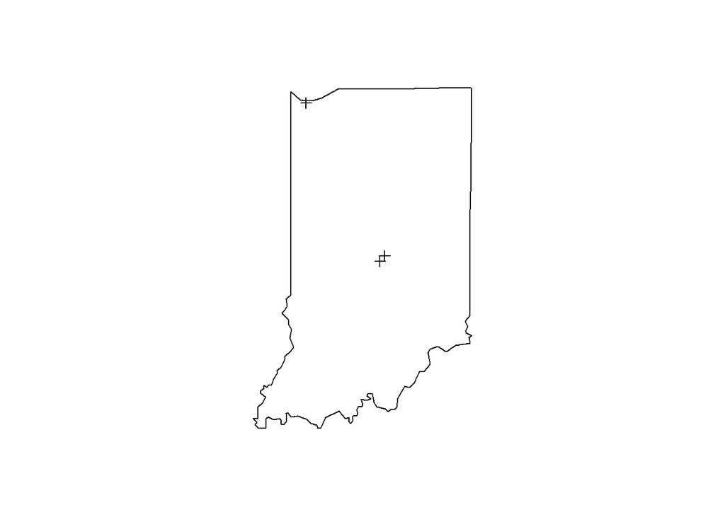

```r
map(database = 'state', regions = 'indiana')
plot(mon_WGS84_sp, add = TRUE)
```

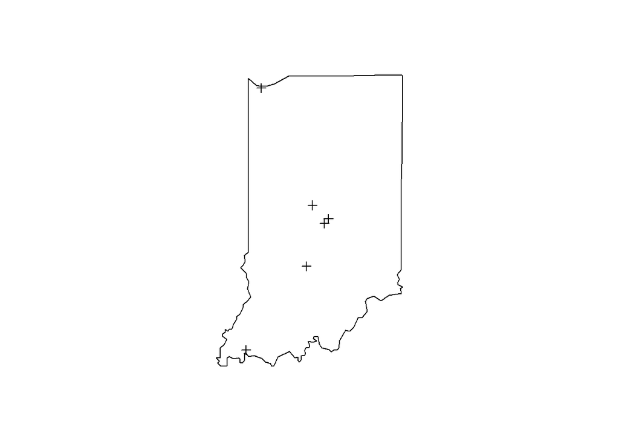

```r
plot(mon_NAD83_sp, add = TRUE)
```

### Further Reading

Below is a list of resources for learning more about what you can do with geographic data in R.

- For a good introduction to using GIS data in R, see [this vignette](https://cran.r-project.org/doc/contrib/intro-spatial-rl.pdf).
- For a comprehensive overview of spatial data and analysis in R, see [Applied Spatial Data Analysis with R](http://www.amazon.com/Applied-Spatial-Data-Analysis-Use/dp/1461476178).
- The [CRAN Task View on Analysis of Spatial Data](https://cran.r-project.org/web/views/Spatial.html) is a comprehensive list of R packages on CRAN that can be used for spatial analysis.